# A comparison of the behaviour of female and male wild boars after an encounter with the Wildschweinschreck

Sarah Helbling

## Abstract

Wild boar populations populations in Europe including Switzerland have grown sharply in the past decades leading to more and more destruction of fields. There are several methods to keep wild boars away from crops with varying sucess rates. One such method is the “Wildschweinschreck”, an acoustic deterrence method which was tested in in Switzerland. Since wild boars can build quite complex social groups that are mostly separated by sex, the focus of this study was on the differences in behaviour of female and male wild boars after an encounter with the “Wildschweinschreck”. The analysis suggests, that females and males differ little in the face of the “Wildschweinschreck”.

## Introduction

Wild boar ( *Sus scrofa* L.) populations in wide parts of Europe, including Switzerland, have sharply grown in the past decades (Goulding 2003; Massei et al. 2015). The main reasons for this increase is the high availability of food in combination with the high reproductive rate of wild boars(Geisser and Reyer 2005). Wild boars often feed in maize and wheat fields causing a lot of damage to the farmers. There are several methods to keep wild boars away from the field, e.g., increasing hunting pressure, electrical fences and acoustic deterrence (Breton 1994; Mazzoni della Stella, Calovi, and Burrini 1995; S. M. Suter and Eyholzer 2010; Vassant 1994).

In a study conducted between 2013 and 2017, all the above mentioned methods were tested and compared, to determine how agricultural land and nature reserves can best be protected from damage by wild boars (S. Suter, Stoller, and Sigris 2018). The authors concluded, that acoustic deterrence is especially suitable directly after the sowing of crops and shortly before maize and wheat are ripe (german: Milchreife). In combination with an increased hunting pressure, acoustic deterrence is even more effective, while electrical fences only keep wild boars away from field when built and maintained well.

The study mainly focused on a comparison of the deterrence methods, but does not include the social structure of wild boars as a factor. The social structure of wild boars might have an influence on the behaviour of female versus male wild boars. Adult male wild boars, for example often live solitarily and have larger home ranges than mother families. These mother families consist of female and young wild boars (Bon et al. 1986; Rosell et al. 2004). Those herds are largely dependent on the leading sows which are responsible for defining when and where to rest or forage, and when to reproduce. Considering these differences of female and male wild boars, this project aims to compare female and male wild boars and their behaviour directly after an encounter with a “Wildschweinschreck”.

## Material and Methods

The data for this project was collected in the context of the [Evalutation eines akustischen Wildschwein-Vergrämungssystems](https://www.zhaw.ch/de/forschung/forschungsdatenbank/projektdetail/projektid/842/). Further information about this study can be found in the [final report](https://www.zhaw.ch/storage/hochschule/medien/bildmaterial/Schlussbericht_Wildschweinschreck.pdf) (language: German) of the study and the [R package](https://computationalmovementanalysis.github.io/ComputationalMovementAnalysisData/index.html) of the data.

In the years 2013-2017 46 fields and 39 wild boars were studied. The acoustic deterrence system fundamentally consisted of two loudspeakers that played species-specific warning noises of different wild boar individuals. Non-species-specific warning noises such as human steps, human voices and sounds of gun shots were added to further deter wild boars (S. Suter, Stoller, and Sigris 2018).

### Material

For the analysis the following data sets of the R package Computational Movement Analysis Data were used:

- wild boar data:
- wildschwein_BE;
- wildschwein_metadata.
- wildschwein schreck data:
- schreck_agenda;
- schreck_locations.

The ground cover data (swisstopo 2022) was retrieved from [geovite](https://geovite.ethz.ch/index.html). The study area lies in the canton Bern on the north-east end of lake Neuchatel.

### Methods

The movement parameter “distance” was created using the Euclidean Distance between consecutive points and multiplying this by a factor of 1.89. This factor was derived from the ratio of the travelled distance observed between a one minute and 15 minute resolution (sampling interval) (S. Suter, Stoller, and Sigris 2018) . The speed is derived from the distance divided by the time-lag in between location fixes. The time-lag differs, as the sampling regime included a location fix every 15 minutes between 17:00 and 05:00, and a location fix every three hours (08:00, 11:00, 14:00, 17:00) during the day.

The descriptions of the ground cover (swissTLM3D Bodenbedeckung) were taken from the Objektkatalog (swisstopo 2022).

## Results

There is no significant difference of the speeds of female and male boars one hour after the encounter with a deterrence.

When comparing the speeds of the different encounters depending on mode and volume of the deterrence, the only significant difference can be seen in males speed dependent on modus ( *Kruskal-Wallis rank sum test, p-value=0.0001409*). At all nine encounters of males, the volume of the deterrence noise was 60 dB[A].

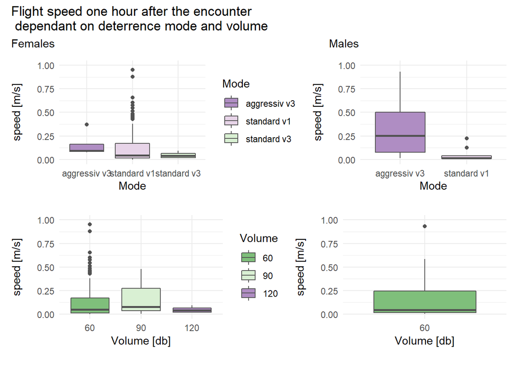

The flight distance of females and males within one hour after the encounters shows no significant difference ( *Wilcoxon rank sum test, alternative=“two-sided”, p-value 0.8955*).

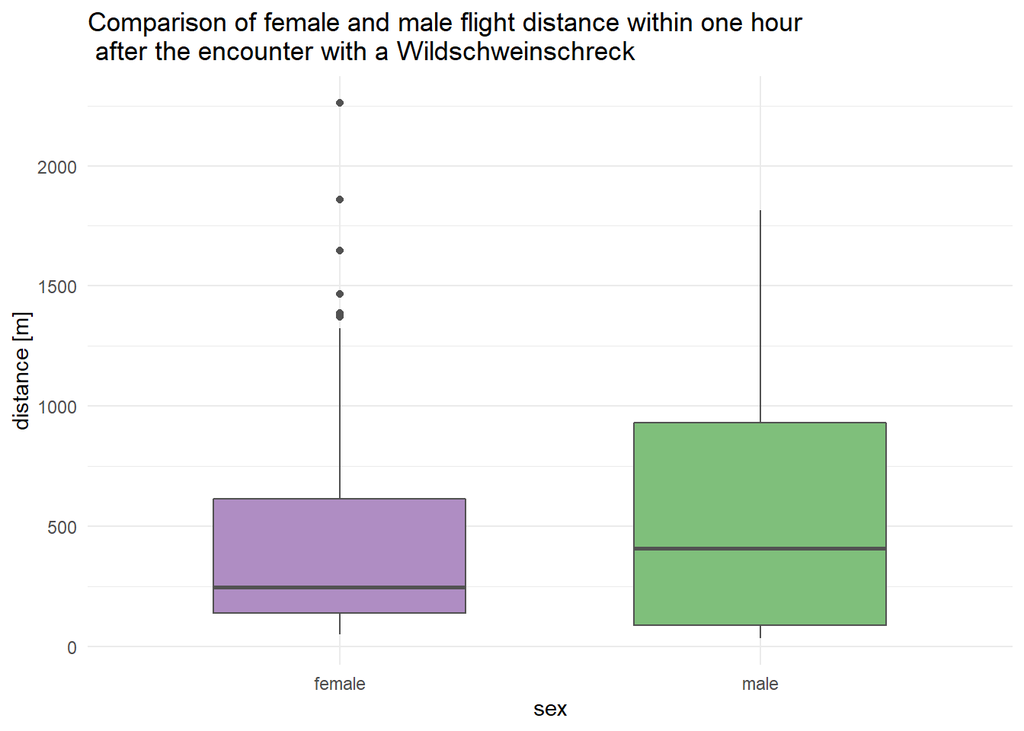

When comparing the different encounters depending on mode and volume of the deterrence, females show no differences in their flight distances. The flight distance depending on mode is significantly different in males.

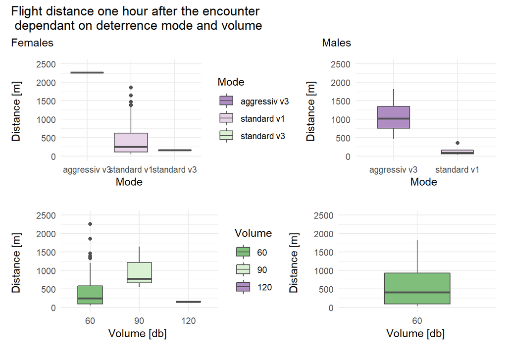

The comparison of the flight distances of the first, second, third, fourth, fifth and sixth hour after the encounter show no significantly differing medians in both females( *Kruskal-Wallis rank sum test, p-value = 0.8669* ) and males ( *Kruskal-Wallis rank sum test, p-value = 0.7951* ).

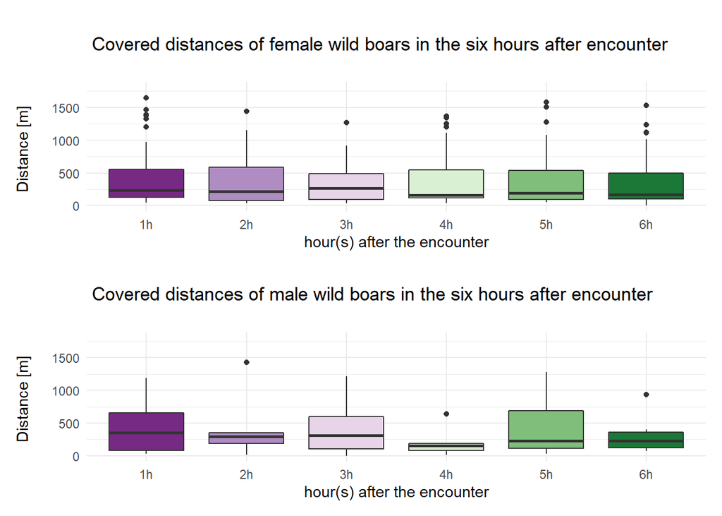

[figure not shown]

The percentage of females staying in agricultural areas in the hours after the encounter declines, while the percentage of points in forest areas rises. From the third hour until the sixth hour after the encounter, there is also a rising amount of wild boars staying in wetland areas.

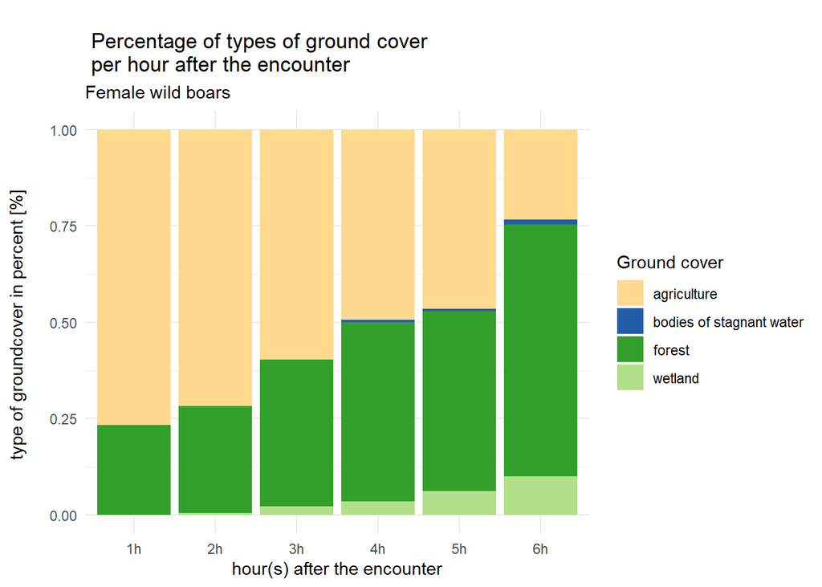

The male wild boars predominantly stay in forest areas. Over the duration of the six hours, the percentage of points in the agricultural areas decreases.

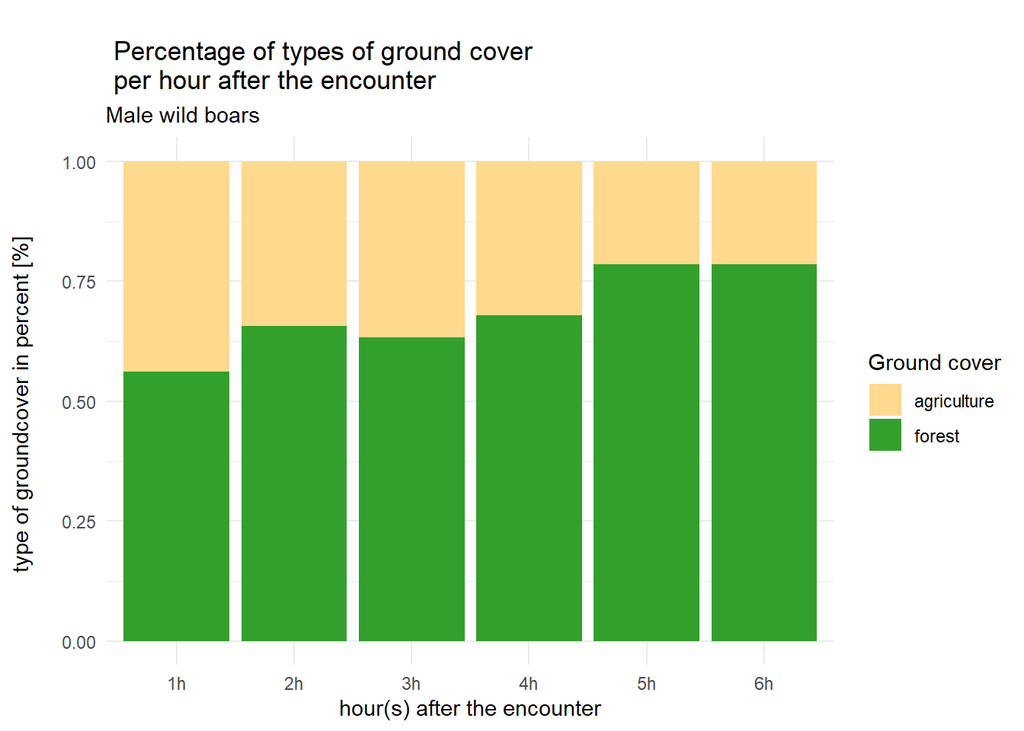

## Discussion

The comparison of both speed and distance within one hour of the encounter show no significant differences between female and male wild boars. Neither flees further or faster than the other group. The mode or volume also do not seem to have an influence on these two measured variables. Only in males the influence of the mode seems to be significant. However, the data suggests, that this difference might be based on the reaction of the two individuals. One individual only came into contact with the “agressiv” mode, while the second individual only encountered deterrence locations on “standard” mode.

What is interesting is the distances the wild boars travelled in the hours after the encounter. All distances are approximately similar, suggesting, that the encounter with deterrence noise did not startle the wild boars significantly and making the flee especially fast or far.

Considering how often the wild boars returned to the deterrence locations as the data suggests, the acoustic deterrence devices do not seem to have a long lasting effect on the wild boars. A boar only encountering a deterrence once seems to be the exception. The overlay of the locations of the boars within the six hours and the ground cover also suggests, that the boars did stay in agricultural areas less and less as the hours went on, but this might simply be a result of sunrise drawing closer and the wild boars returning to their resting sites where they are well hidden.

### Difficulties

First and foremost, this project was supposed to compare female and male wild boars in their potentially different behaviour after an encounter with a “Wildschweinschreck” based on the hypothesis, that the two sexes have different social structures. However, with the available data, such a comparison was not possible. The data does show, that the females have a smaller home range than the males and that they stay within this established area (S. Suter, Stoller, and Sigris 2018) . Nonetheless it is hard to tell whether the sex itself has a direct influence on the reaction upon the encounter with acoustic deterrence.

One major problem is the overall number of encounters. While the rarity of males made certain comparisons impossible, the overall number of encounters was influenced by the radius of the buffer around the deterrence locations. Since wild boars prefer the cover forests offer over large stretches of open field, the speakers were placed close to forest edges and oriented in their direction. To avoid the buffers to overlap too much with the forests, where the noise would be dampened by the dense vegetation, the buffers were kept rather small at 250 meters. What also influenced the number of encounters was the removal of encounters that happened during the day. As (S. Suter, Stoller, and Sigris 2018) mentions, the deterrence noises are only played after sunset, as the systems are equipped with a light sensor. Despite being primarily nocturnal, there were a lot of encounters during dusk, when the deterrence systems were not yet active.

### Conclusion

This project was an attempt to determine if there are differences between female and male wild boars as they flee from noises that are meant to deter them. What it showed is that even with a total of 327’255 location fixes that were collected over the duration of four years, there are little to no encounters between wild boars and the “Wildschweinschreck”. Or if there where encounters, many happend while the “Wildschweinschreck” was not active and even if it was active, it did not influence neither females nor males to run faster or further to get away from the source of the noise.

Further research would be needed to compare e.g., the long lasting effects of the “Wildschweinschreck” on individuals or possible behaviour differences during longer times without deterring noises and during times of active deterring noises. An aspect that was rather ignored during this project but might have an impact on the efficiency of the “Wildschweinschreck” as well is the dispersion of the sound.

# Bibliography

Bon, Richard, R Campan, M Dardaillon, G Demeautis, Georges Gonzalez, and P Teillaud. 1986. “Comparative Study of the Seasonal Variations of the Social Structures in Three French Wild Ungulates.” *Wissenschaftliche Zeitschrift Der Humboldt Universität Zu Berlin. Mathematisch-Naturwissenschaftliche Reihe* 35 (3): 254258.

Breton, D. 1994. “La Limitation Des Dégâts de Sanglier Par La Pose de Clôtures Électriques Dans Le Département de La Haute-Marne.” *Bull Mens Off Natl Chasse* 191 (Numéro): 96100.

Geisser, Hannes, and Heinz-Ulrich Reyer. 2005. “The Influence of Food and Temperature on Population Density of Wild Boar Sus Scrofa in the Thurgau (Switzerland).” *Journal of Zoology* 267 (1): 8996.

Goulding, Martin. 2003. *Wild Boar in Britain*. Whittet Books.

Massei, Giovanna, Jonas Kindberg, Alain Licoppe, Dragan Gačić, Nikica Šprem, Jiří Kamler, Eric Baubet, et al. 2015. “Wild Boar Populations up, Numbers of Hunters down? A Review of Trends and Implications for Europe.” *Pest Management Science* 71 (4): 492500.

Mazzoni della Stella, R, F Calovi, and L Burrini. 1995. “The Wild Boar Management in a Province of the Central Italy.” *IBEX Journal of Mountain Ecology* 3: 213216.

Rosell, CARME, FERRAN Navas, SERGI Romero, and IGNASI de Dalmases. 2004. “Activity Patterns and Social Organization of Wild Boar (Sus Scrofa, l.) In a Wetland Environment: Preliminary Data on the Effects of Shooting Individuals.” *Galemys* 16: 157166.

Suter, S. M., and R. Eyholzer. 2010. “Interkantonales Wildschweinprojekt FR-BE-VD, Räumliche Und Zeitliche Habitatnutzung, Schäden an Landwirtschaftlichen Kulturen Und Einfluss Der Jagd Auf Das Raumverhalten Der Wildschweine Am Südostufer Des Neuenburgersees.”

Suter, Stefan, Sandro Stoller, and Benjamin Sigris. 2018. “Prävention von Wildschweinschäden in Der Landwirtschaft Und Management von Wildschweinen in Schutzgebieten Schlussbericht.”

swisstopo. 2022. “Objektkatalog swissTLM3D 2.0.”

Vassant, J. 1994. “Les Techniques de Prévention Des Dégâts de Sangliers.” *Bull Mens Off Natl Chasse* 191: 9093.